# ESM206 Lab 10

Anna Abelman

12/3/2019

## Objectives:

- mutliple linear regression
- out first map with sf and ggplot

### 1. Multiple linear regression: SLO home prices

```r
homes <- read_csv("slo_homes.csv") %>%
  clean_names()
beep(3)
praise()
```

```
## [1] "You are excellent!"
```

```r
praise("You are totally ${adjective}! Super ${EXCLAMATION}!")
```

```
## [1] "You are totally impressive! Super WOWIE!"
```

```r
homes_sub <- homes %>%
  filter(city %in% c("San Luis Obispo", "Atascadero", "Arroyo Grande"))
```

Are there correlations between variables that we’d consider while trying to model home price?

```r
homes_cor <- cor(homes_sub[2:5])
homes_cor
```

```
##               price  bedrooms bathrooms     sq_ft
## price     1.0000000 0.3115258 0.4991453 0.6618575
## bedrooms  0.3115258 1.0000000 0.7519186 0.6960233
## bathrooms 0.4991453 0.7519186 1.0000000 0.8046112
## sq_ft     0.6618575 0.6960233 0.8046112 1.0000000
```

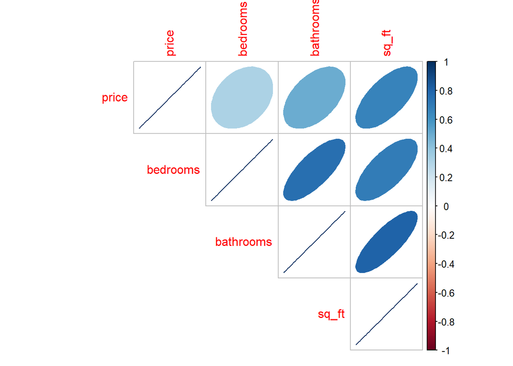

```r
corrplot(homes_cor,
         method = "ellipse",
         type = "upper")
```

is there any reason to think this is no a multi linear relationship?

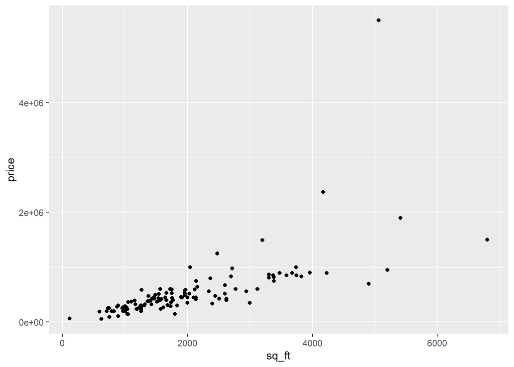

```r
ggplot(data = homes_sub, aes(x = sq_ft, y = price))+
  geom_point()
```

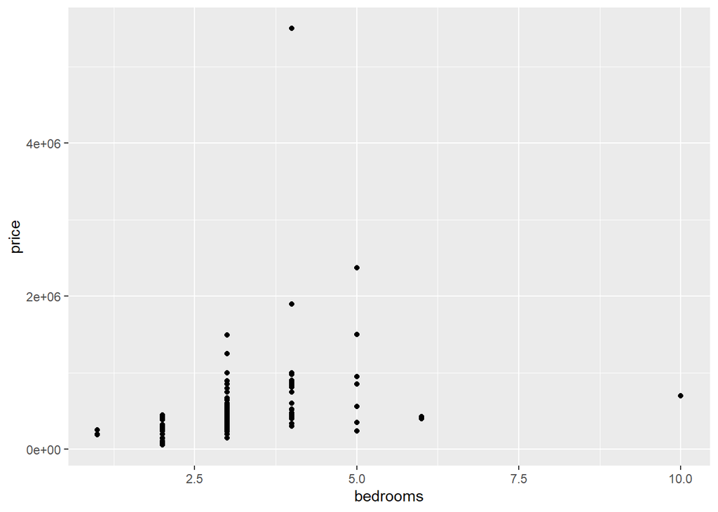

```r
ggplot(data = homes_sub, aes(x = bedrooms, y = price))+
  geom_point()
```

Let’s start with a complete model (includes city, bedrooms, bathroom, sq_ft, and sale status):

```r
homes_lm <- lm(price ~ city + bedrooms + bathrooms + sq_ft + status, data = homes_sub)

summary(homes_lm)
```

```
##
## Call:
## lm(formula = price ~ city + bedrooms + bathrooms + sq_ft + status,
##     data = homes_sub)
##
## Residuals:
##     Min      1Q  Median      3Q     Max
## -843938 -115963  -12298  109718 3445077
##
## Coefficients:
##                       Estimate Std. Error t value Pr(>|t|)
## (Intercept)          184130.93  143368.84   1.284  0.20157
## cityAtascadero      -167396.39   78701.95  -2.127  0.03552 *
## citySan Luis Obispo   31018.14  114895.10   0.270  0.78766
## bedrooms            -161645.51   49414.32  -3.271  0.00141 **
## bathrooms             48692.04   52408.63   0.929  0.35476
## sq_ft                   389.12      53.17   7.318 3.43e-11 ***
## statusRegular        303964.64  105942.81   2.869  0.00488 **
## statusShort Sale     -19828.56   86335.35  -0.230  0.81875
## ---
## Signif. codes:  0 '***' 0.001 '**' 0.01 '*' 0.05 '.' 0.1 ' ' 1
##
## Residual standard error: 380600 on 117 degrees of freedom
## Multiple R-squared:  0.5682, Adjusted R-squared:  0.5424
## F-statistic:    22 on 7 and 117 DF,  p-value: < 2.2e-16
```

```r
# estimates are the coefficients in the linear equations for each variable
#reference levels would be city - Arroyo Grande and status - Foreclosure
# bedroom is an example of possible colinearity because it is decrease -161645 each time for a bedroom
```

This model significantly predict the home price

Now let’s try another version of the model: - just using sq_ft as a measure of home size

```r
homes_lm2 <- lm(price ~ city + sq_ft + status, data = homes_sub)
summary(homes_lm2)
```

```
##
## Call:
## lm(formula = price ~ city + sq_ft + status, data = homes_sub)
##
## Residuals:
##     Min      1Q  Median      3Q     Max
## -653118 -120914   -8844  101402 3644738
##
## Coefficients:
##                       Estimate Std. Error t value Pr(>|t|)
## (Intercept)         -105820.71  118697.40  -0.892   0.3745
## cityAtascadero      -182586.90   80683.44  -2.263   0.0254 *
## citySan Luis Obispo   70278.97  115846.31   0.607   0.5452
## sq_ft                   325.03      31.54  10.306   <2e-16 ***
## statusRegular        315441.26  109749.65   2.874   0.0048 **
## statusShort Sale      31284.44   87356.11   0.358   0.7209
## ---
## Signif. codes:  0 '***' 0.001 '**' 0.01 '*' 0.05 '.' 0.1 ' ' 1
##
## Residual standard error: 395100 on 119 degrees of freedom
## Multiple R-squared:  0.5268, Adjusted R-squared:  0.5069
## F-statistic: 26.49 on 5 and 119 DF,  p-value: < 2.2e-16
```

```r
beep(6)
praise()
```

```
## [1] "You are magnificent!"
```

AIC:

```r
AIC(homes_lm)
```

```
## [1] 3576.834
```

```r
AIC(homes_lm2)
```

```
## [1] 3584.3
```

```r
# homes_lm is lower so it is the better model, however, it should be the least interesting part and conceptually should make the most sense
#does it make sense conceptually that bedrooms and bathrooms should increase or decrease the price of the house? the sq_ft measure is best to determine the price

#model 2 is the conceptually more sound
```

### Now: check the assumptions for normality and homoscedasticity

- normality refers to the distribution of the residuals NOT THE DISTRIBUTION OF THE DATA

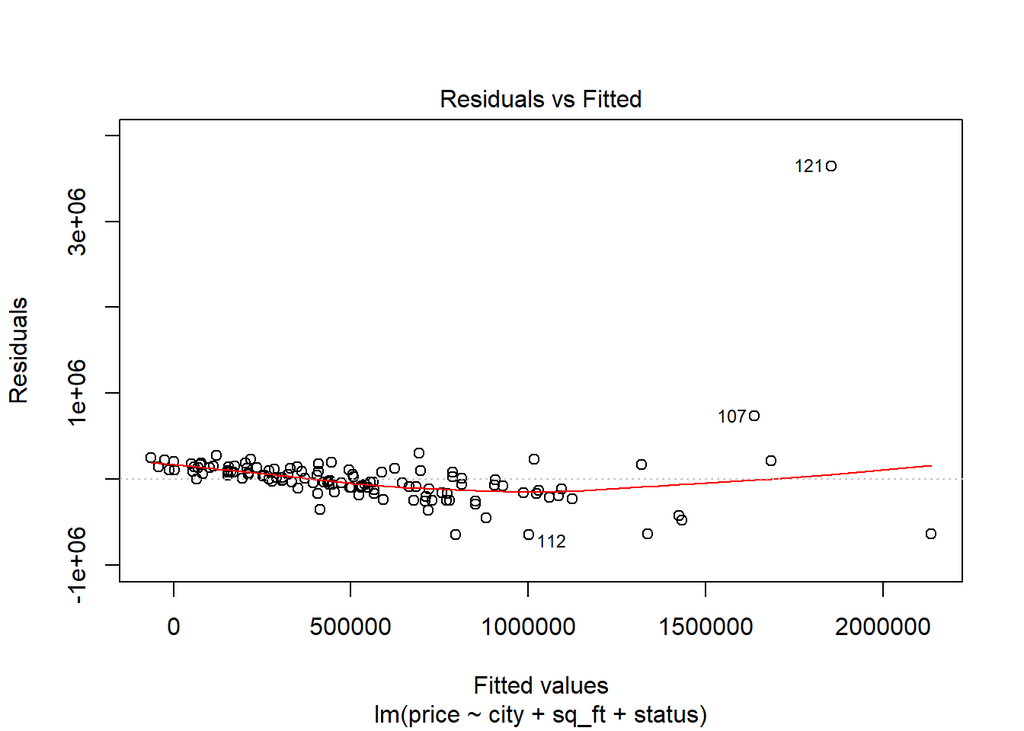

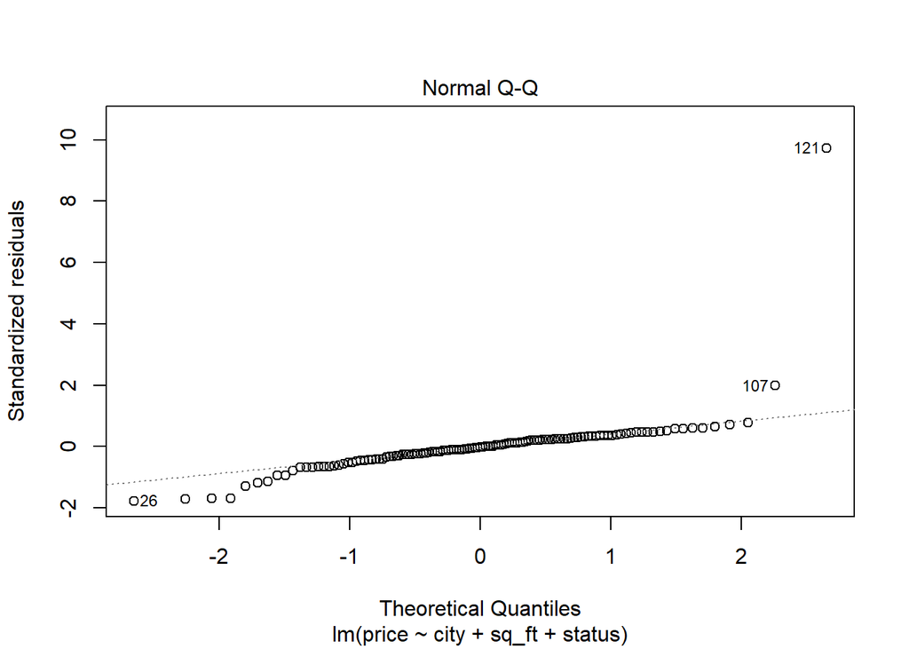

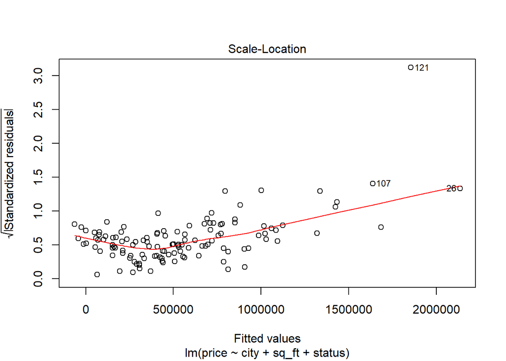

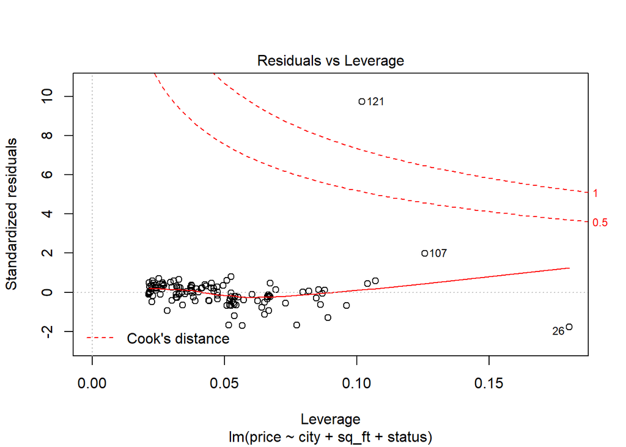

```r
plot(homes_lm2)
```

```r
#1: actual residual values; are the variances constant or changing throughoout? --> looks like the assumption of constant variances of residuals (homoscedasticity) is OK
#2: qq plot - is there are linear relationship? --> straight line so normally distribution
# cook's distance: comparing leverage on a model

praise()
```

```
## [1] "You are swell!"
```

Make a nice regression table:

```r
stargazer(homes_lm2, type = "html")
```

|  | *Dependent variable:* |
| --- | --- |
|  | price |
| cityAtascadero | -182,586.900** |
|  | (80,683.440) |
| citySan Luis Obispo | 70,278.970 |
|  | (115,846.300) |
| sq_ft | 325.028*** |
|  | (31.538) |
| statusRegular | 315,441.300*** |
|  | (109,749.700) |
| statusShort Sale | 31,284.440 |
|  | (87,356.110) |
| Constant | -105,820.700 |
|  | (118,697.400) |
| Observations | 125 |
| R<sup>2</sup> | 0.527 |
| Adjusted R<sup>2</sup> | 0.507 |
| Residual Std. Error | 395,084.400 (df = 119) |
| F Statistic | 26.491*** (df = 5; 119) |
| *Note:* | p<0.1; p<0.05; p<0.01 |

Let’s make some predictions for how price based on a new data frame from of home characteristics

Make sure that the variables we create for the new data match the variables that the model will be looking for to make new predictions.

```r
new_df <- data.frame(
  city = rep(c("San Luis Obispo", "Arroyo Grande", "Atascadero"), each = 10),
  sq_ft = rep(seq(1000, 5000, length = 10)),
  status = "Regular"
)
```

Now: We’ll make predictions for home rpice based on that new data:

```r
predict_df <- predict(homes_lm2, newdata = new_df)
predict_df
```

```
##         1         2         3         4         5         6         7
##  604927.5  749384.3  893841.2 1038298.1 1182754.9 1327211.8 1471668.7
##         8         9        10        11        12        13        14
## 1616125.5 1760582.4 1905039.3  534648.5  679105.4  823562.2  968019.1
##        15        16        17        18        19        20        21
## 1112476.0 1256932.8 1401389.7 1545846.6 1690303.4 1834760.3  352061.6
##        22        23        24        25        26        27        28
##  496518.5  640975.3  785432.2  929889.1 1074345.9 1218802.8 1363259.7
##        29        30
## 1507716.5 1652173.4
```

```r
#bind together the new_df with the predictions:
full_data <- data.frame(new_df, predict_df)
full_data
```

```
##               city    sq_ft  status predict_df
## 1  San Luis Obispo 1000.000 Regular   604927.5
## 2  San Luis Obispo 1444.444 Regular   749384.3
## 3  San Luis Obispo 1888.889 Regular   893841.2
## 4  San Luis Obispo 2333.333 Regular  1038298.1
## 5  San Luis Obispo 2777.778 Regular  1182754.9
## 6  San Luis Obispo 3222.222 Regular  1327211.8
## 7  San Luis Obispo 3666.667 Regular  1471668.7
## 8  San Luis Obispo 4111.111 Regular  1616125.5
## 9  San Luis Obispo 4555.556 Regular  1760582.4
## 10 San Luis Obispo 5000.000 Regular  1905039.3
## 11   Arroyo Grande 1000.000 Regular   534648.5
## 12   Arroyo Grande 1444.444 Regular   679105.4
## 13   Arroyo Grande 1888.889 Regular   823562.2
## 14   Arroyo Grande 2333.333 Regular   968019.1
```

[output cut: 16 more lines]

Now plot in ggplot2:

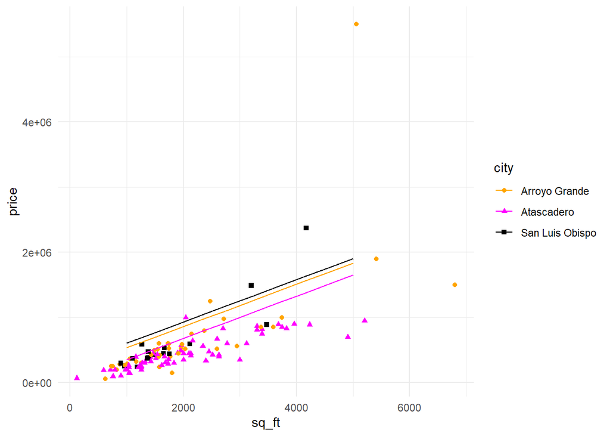

```r
ggplot()+
  geom_point(data = homes_sub, aes(x = sq_ft, y = price, color = city, pch = city))+
  geom_line(data = full_data, aes(x = sq_ft, y = predict_df, color = city))+
  scale_color_manual(values = c("orange", "magenta", "black"))+
  theme_minimal()
```

### Our first map

- great because: sticky geometries

```r
dams <- read_csv("ca_dams.csv") %>%
  clean_names() %>%
  drop_na(latitude) %>%
  drop_na(longitude) %>%
  drop_na(year_completed)
```

convert our data frame to an sf object using st_as_sf:

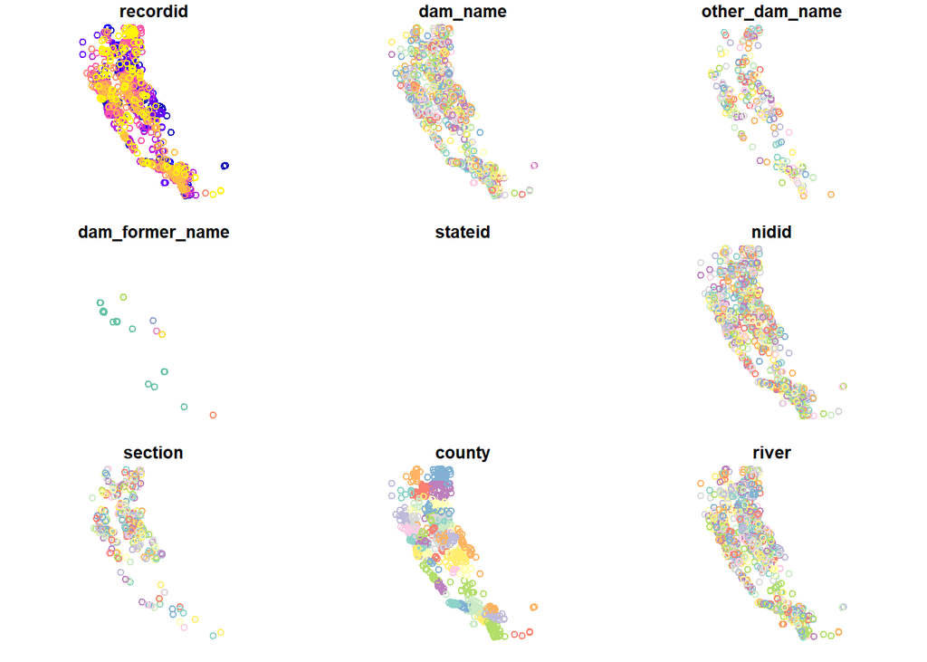

```r
dams_sf <- st_as_sf(dams, coords = c("longitude", "latitude"))
st_crs(dams_sf) <- 4326

plot(dams_sf)
```

Read in the California border polygon data:

```r
library(here)
```

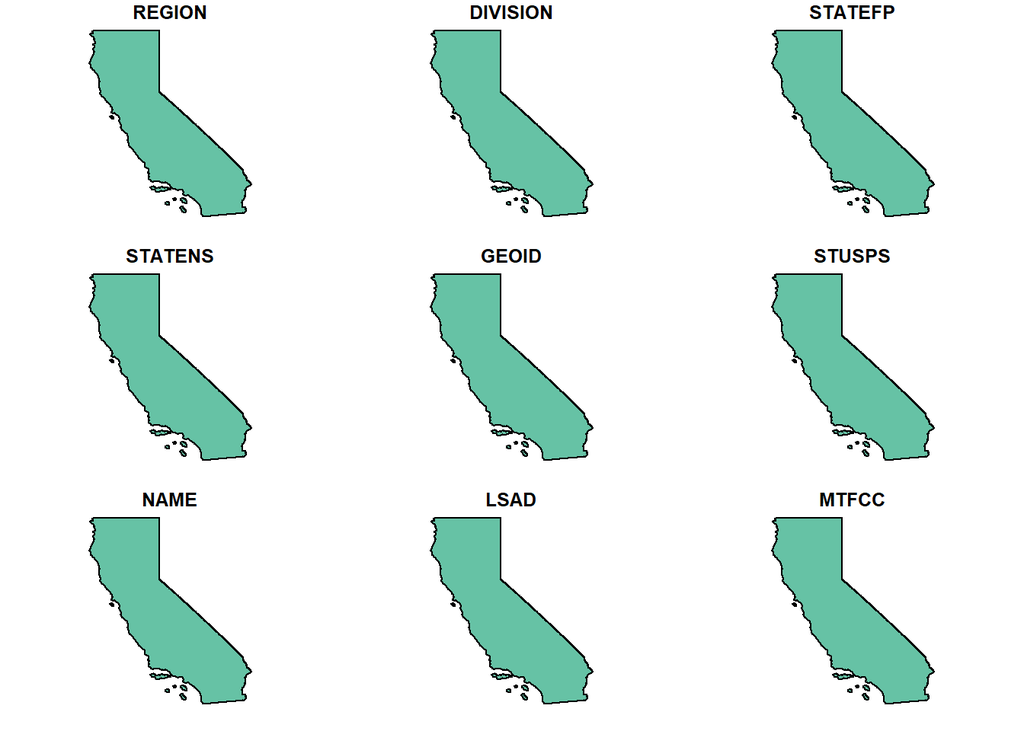

```r
ca_border <- read_sf(here::here("ca_state_border"), layer = "CA_State_TIGER2016")

plot(ca_border)
```

Now let’s plot them together with ggplot2:

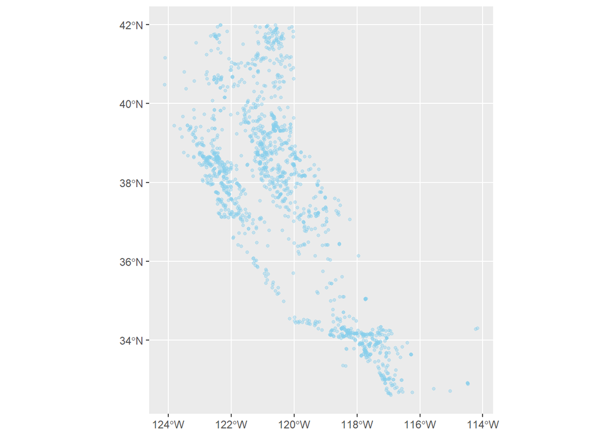

```r
ggplot()+
  geom_sf(data = dams_sf, color = "skyblue", size = 1, alpha = 0.4)
```

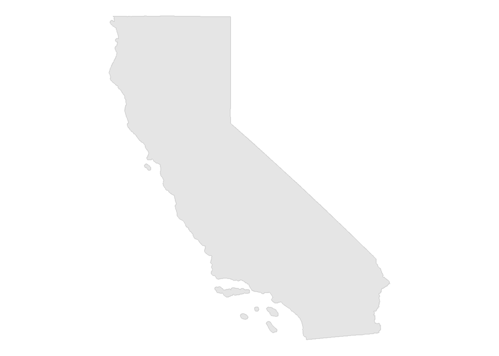

```r
ggplot()+
  geom_sf(data = ca_border, color = "light gray", color = "black")+
  theme_void()
```

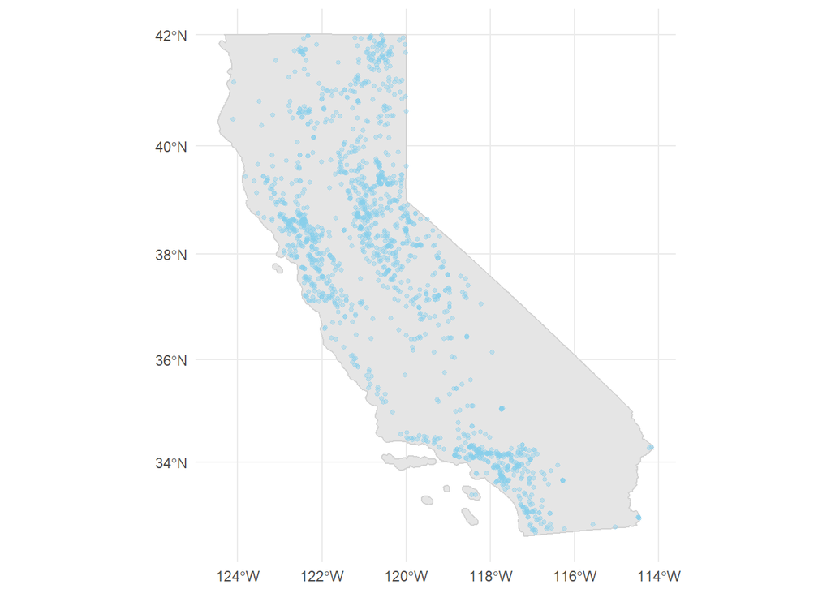

```r
ggplot()+
  geom_sf(data = ca_border, color = "light gray", color = "black")+
  geom_sf(data = dams_sf, color = "skyblue", size = 1, alpha = 0.4)+
  theme_minimal()
```

Now let’s animate it with gganimate

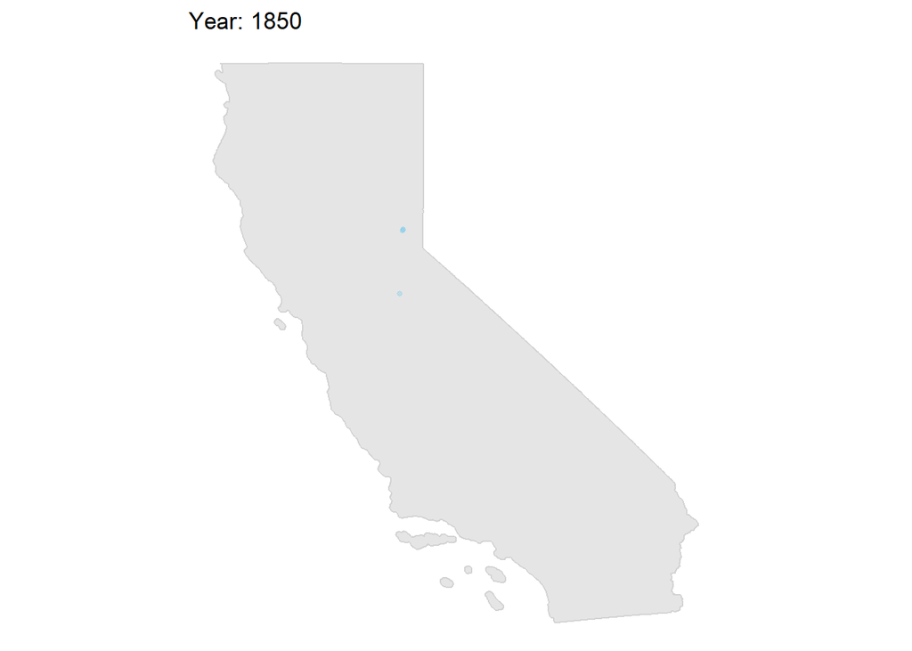

```r
ggplot()+
  geom_sf(data = ca_border, color = "light gray", color = "black")+
  geom_sf(data = dams_sf, color = "skyblue", size = 1, alpha = 0.4)+
  theme_void()+
  labs(title = 'Year: {round(frame_time, 0)}')+
  transition_time(year_completed)+
  shadow_mark()
```